# Derivation of the gamma 0

2026-02-03

## Derive the value of $\gamma_0$

We want to target an overall compliance of 95%. The probability of compliance for each arm is defined by the logistic regression model (4.1). The overall compliance is therefore the sum of the compliances for each treatment group, weighted by their respective sample sizes.

For each treatment arm we define: $A0$ and $A1$ as the terms in the logistic regression that don’t depend on $\gamma_0$, $w_0:=\frac{n_{\textrm{ctrl}}}{n_{\textrm{ctrl}}+n_{\textrm{trt}}}$, $w_1:=\frac{n_{\textrm{trt}}}{n_{\textrm{ctrl}}+n_{\textrm{trt}}}$ for the control (0) arm and the treatment arm (1) respectively. Given all other parameters we can solve this for $\gamma_0$ symbolically:

```python
from sympy import *
```

Define symbols and state assumptions:

```python
w0 = Symbol("w0", real=True, positive=True)
w1 = Symbol("w1", real=True, positive=True)
gamma0 = Symbol("gamma0", real=True)
A0 = Symbol("A0", real=True)
A1 = Symbol("A1", real=True)
p = Symbol("p", real=True, positive=True)
```

Plug in definition of logistic function $x\mapsto \frac{1}{1+\exp(x)}$:

```python
my_expr = w1*(1/(1+exp(-gamma0-A1))) + w0*(1/(1+exp(-gamma0-A0))) - p
```

Sovle for $\gamma_0$

```python
solutions = solve(my_expr, gamma0)
```

Which gives us two solutions:

```python
len(solutions)
```

```
## 2
```

```python
solutions[0]
```

```
## -A0 - A1 + log((-p*exp(A0) - p*exp(A1) + w0*exp(A0) + w1*exp(A1) - sqrt(p**2*exp(2*A0) + p**2*exp(2*A1) - 2*p**2*exp(A0 + A1) - 2*p*w0*exp(2*A0) + 2*p*w0*exp(A0 + A1) - 2*p*w1*exp(2*A1) + 2*p*w1*exp(A0 + A1) + w0**2*exp(2*A0) + 2*w0*w1*exp(A0 + A1) + w1**2*exp(2*A1)))/(p - w0 - w1)) - log(2)
```

```python
solutions[1]
```

```
## -A0 - A1 + log((-p*exp(A0) - p*exp(A1) + w0*exp(A0) + w1*exp(A1) + sqrt(p**2*exp(2*A0) + p**2*exp(2*A1) - 2*p**2*exp(A0 + A1) - 2*p*w0*exp(2*A0) + 2*p*w0*exp(A0 + A1) - 2*p*w1*exp(2*A1) + 2*p*w1*exp(A0 + A1) + w0**2*exp(2*A0) + 2*w0*w1*exp(A0 + A1) + w1**2*exp(2*A1)))/(p - w0 - w1)) - log(2)
```

## R-implementation and check

```r
library("CI.RCT.Sim")
library("SimDesign")
```

As a reference/check: a naive implementation by numeric root-finding:

```r
vaccine_scenario_set_gamma_0_numeric <- function(Design){
  set_gamma_0_rowwise <- function(condition){
    # plug-in mean for W, V
    A0 <- condition$gamma_W * condition$p_W +
      condition$gamma_V * condition$p_V

    A1 <- condition$gamma_W * condition$p_W +
      condition$gamma_V * condition$p_V +
      condition$gamma_A +
      condition$gamma_AW * condition$p_W

    f <- function(gamma_0){
      ((condition$n_trt)/(condition$n_trt + condition$n_ctrl)) * binomial()$linkinv(gamma_0 + A1) +
        ((condition$n_ctrl)/(condition$n_trt + condition$n_ctrl)) * binomial()$linkinv(gamma_0 + A0) -
        condition$overall_compliance
    }

    gamma_0 <- uniroot(
      f, lower=0, upper=0.1, extendInt = "upX",
      check.conv=TRUE,
      tol=.Machine$double.eps^0.5
    )$root

    gamma_0
  }

  Design$gamma_0 <- Design |>
    split(1:nrow(Design)) |>
    sapply(set_gamma_0_rowwise)

  Design
}
```

Implementation based on the symbolic math solution:

```r
vaccine_scenario_set_gamma_0 <- function(Design){
  set_gamma_0_rowwise <- function(condition){
    # plug-in mean for W, V
    A0 <- condition$gamma_W * condition$p_W +
      condition$gamma_V * condition$p_V

    A1 <- condition$gamma_W * condition$p_W +
      condition$gamma_V * condition$p_V +
      condition$gamma_A +
      condition$gamma_AW * condition$p_W

    w1 <- condition$n_trt  / (condition$n_trt + condition$n_ctrl)
    w0 <- condition$n_ctrl / (condition$n_trt + condition$n_ctrl)
    p <- condition$overall_compliance

    # derived with sympy
    log_solution_1 <-
        (-p*exp(A0) - p*exp(A1) + w0*exp(A0) + w1*exp(A1) - sqrt(p^2*exp(2*A0) + p^2*exp(2*A1) - 2*p^2*exp(A0 + A1) - 2*p*w0*exp(2*A0) + 2*p*w0*exp(A0 + A1) - 2*p*w1*exp(2*A1) + 2*p*w1*exp(A0 + A1) + w0^2*exp(2*A0) + 2*w0*w1*exp(A0 + A1) + w1^2*exp(2*A1)))*exp(-A0 - A1)/(p - w0 - w1)

    # derived with sympy
    log_solution_2 <-
      (-p*exp(A0) - p*exp(A1) + w0*exp(A0) + w1*exp(A1) + sqrt(p^2*exp(2*A0) + p^2*exp(2*A1) - 2*p^2*exp(A0 + A1) - 2*p*w0*exp(2*A0) + 2*p*w0*exp(A0 + A1) - 2*p*w1*exp(2*A1) + 2*p*w1*exp(A0 + A1) + w0^2*exp(2*A0) + 2*w0*w1*exp(A0 + A1) + w1^2*exp(2*A1)))*exp(-A0 - A1)/(p - w0 - w1)

    # check which solution works (log of something > 0)
    if((log_solution_1 > 0) && (log_solution_2 <= 0)){
      gamma_0 <- log(log_solution_1) - log(2)
    } else if((log_solution_2 > 0) && (log_solution_1 <= 0)){
      gamma_0 <- log(log_solution_2) - log(2)
    } else {
      stop("No valid solution")
    }

    gamma_0
  }

  Design$gamma_0 <- Design |>
    split(1:nrow(Design)) |>
    sapply(set_gamma_0_rowwise)

  Design
}
```

## Compare Solutions

Calculate the values with the two implementations and check, if they are the same:

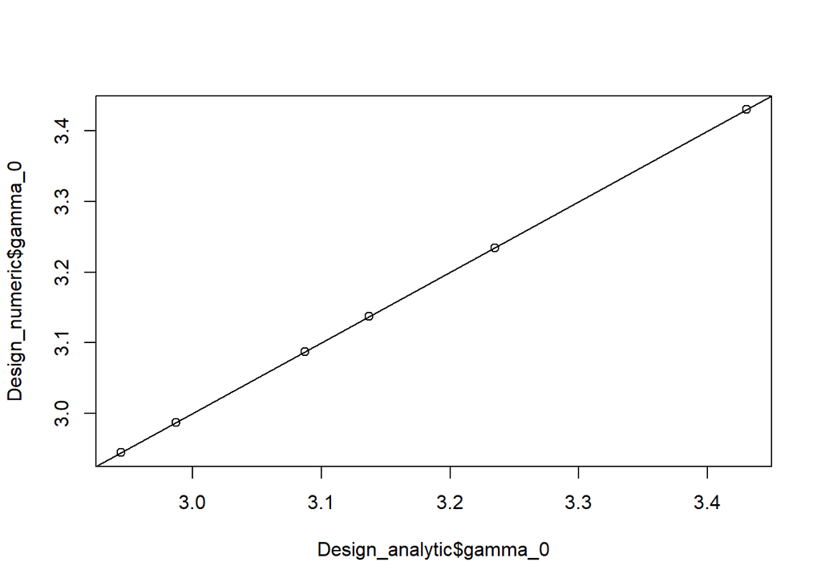

```r
Design <- vaccine_scenario(print=FALSE)
Design$overall_compliance <- 0.95

Design_analytic <- vaccine_scenario_set_gamma_0(Design)
Design_numeric  <- vaccine_scenario_set_gamma_0_numeric(Design)

plot(Design_analytic$gamma_0, Design_numeric$gamma_0)
abline(0,1)
```

## Check by simulation

Do we actually hit the target of overall compliance?

```r
Design_analytic$beta_A1 <- 0.1

# just take the means / proportions of the compliance C
Analyse <- function(condition, dat, fixed_objects) {
    ret <- nc(mean = mean(dat$C))
    ret
}

# mean and variance of the proportions
Summarise <- Summarise <- function(condition, results, fixed_objects) {
    ret <- c(mean=mean(results$mean), var=var(results$mean))
    ret
}

# run simulation with 1000 replications
res <- runSimulation(
  design = Design_analytic,
  replications = 1000,
  generate = generate_vaccine,
  analyse = Analyse,
  summarise = Summarise
)
```

And the results look quite ok:

```r
res$mean - 0.95
```

```
##  [1] -0.00048 -0.00040 -0.00084 -0.00158 -0.00483  0.00024  0.00002  0.00142
##  [9] -0.00144 -0.00097  0.00054 -0.00060 -0.00046 -0.00054  0.00006  0.00060
## [17] -0.00011
```